# Project 2

Grace Holliday and Damon D’Ambrosio

2023-07-06

# Data Channel: **data_channel_is_world**

# Introduction

The goal/purpose of this project is to explore the factors influencing the amount of shares (popularity) of articles published by Mashable in a period of two years.

The data includes 39,644 observations of 61 total variables. For our exploration, we will use variables num_imgs, num_videos, num_keywords, weekday_is variables (including is_weekend), global_subjectivity (Text subjectivity),global_sentiment_polarity (Text sentiment polarity), global_rate_positive_words (Rate of positive words in the content), global_rate_negative_words (Rate of negative words in the content), title_subjectivity, and title_polarity, to explore the target variable (shares).

The methods we will use to model the response include:  
- Linear Regression  
- Random Forest  
- Boosted Tree

# Data

```r
dat <- read_csv("OnlineNewsPopularity.csv")
# Subset data to variables we want
dat <- dat[,-c(1:9,12,20:31,39:44, 49:55,58,59)]

# Subsetting to correct channel(s)
col <- params[[1]][1]
if(col=="data_channel_is_lifestyle")
{
  dattype <- subset(dat,data_channel_is_lifestyle==1)
} else if(col=="data_channel_is_entertainment")
{
  dattype <- subset(dat,data_channel_is_entertainment==1)
} else if(col=="data_channel_is_bus")
{
  dattype <- subset(dat,data_channel_is_bus==1)
} else if(col=="data_channel_is_socmed")
{
  dattype <- subset(dat,data_channel_is_socmed==1)
} else if(col=="data_channel_is_tech")
{
  dattype <- subset(dat,data_channel_is_tech==1)
} else if(col=="data_channel_is_world")
{
  dattype <- subset(dat,data_channel_is_world==1)
}

# Removing data channel columns
dattype <- dattype[,-c(4:9)]
```

# Summarizations

First, we will produce basic summary statistics and plots about the training data. To do this, we first need to divide the data into a training and test set.

```r
# First, establishing every categorical variable as a character
# so can change the factor
dattype$weekday_is_monday <- as.character(dattype$weekday_is_monday)
dattype$weekday_is_tuesday <- as.character(dattype$weekday_is_tuesday)
dattype$weekday_is_wednesday <- as.character(dattype$weekday_is_wednesday)
dattype$weekday_is_thursday <- as.character(dattype$weekday_is_thursday)
dattype$weekday_is_friday <- as.character(dattype$weekday_is_friday)
dattype$weekday_is_saturday <- as.character(dattype$weekday_is_saturday)
dattype$weekday_is_sunday <- as.character(dattype$weekday_is_sunday)

# Creating single variable for day 1 = Monday 2 = Tuesday 3 = Wednesday
# 4 = Thursday 5 = Friday 6 = Saturday 7 = Sunday 0 if no day, also
# making these a factor and not 0 and 1 for ensemble models

for(i in 1:nrow(dattype))
{
  if(dattype[i,4]==1)
  {
    dattype[i,19] <- 'Monday'
    dattype[i,4] <- 'Y'
    dattype[i,5] <- 'N'
    dattype[i,6] <- 'N'
    dattype[i,7] <- 'N'
    dattype[i,8] <- 'N'
    dattype[i,9] <- 'N'
    dattype[i,10] <- 'N'
  }
  else if (dattype[i,5]==1)
  {
    dattype[i,19] <- 'Tuesday'
    dattype[i,4] <- 'N'
    dattype[i,5] <- 'Y'
    dattype[i,6] <- 'N'
    dattype[i,7] <- 'N'
    dattype[i,8] <- 'N'
    dattype[i,9] <- 'N'
    dattype[i,10] <- 'N'
  }
  else if (dattype[i,6]==1)
  {
    dattype[i,19] <- 'Wednesday'
    dattype[i,6] <- 'Y'
    dattype[i,4] <- 'N'
    dattype[i,5] <- 'N'
    dattype[i,7] <- 'N'
    dattype[i,8] <- 'N'
    dattype[i,9] <- 'N'
    dattype[i,10] <- 'N'
  }
  else if (dattype[i,7]==1)
  {
    dattype[i,19] <- 'Thursday'
    dattype[i,6] <- 'N'
    dattype[i,4] <- 'N'
    dattype[i,5] <- 'N'
    dattype[i,7] <- 'Y'
    dattype[i,8] <- 'N'
    dattype[i,9] <- 'N'
    dattype[i,10] <- 'N'
    }
  else if (dattype[i,8]==1)
  {
    dattype[i,19] <- 'Friday'
    dattype[i,6] <- 'N'
    dattype[i,4] <- 'N'
    dattype[i,5] <- 'N'
    dattype[i,7] <- 'N'
    dattype[i,8] <- 'Y'
    dattype[i,9] <- 'N'
    dattype[i,10] <- 'N'
  }
  else if (dattype[i,9]==1)
  {
    dattype[i,19] <- 'Saturday'
    dattype[i,6] <- 'N'
    dattype[i,4] <- 'N'
    dattype[i,5] <- 'N'
    dattype[i,7] <- 'N'
    dattype[i,8] <- 'N'
    dattype[i,9] <- 'Y'
    dattype[i,10] <- 'N'
  }
  else if (dattype[i,10]==1)
  {
    dattype[i,19] <- 'Sunday'
    dattype[i,6] <- 'N'
    dattype[i,4] <- 'N'
    dattype[i,5] <- 'N'
    dattype[i,7] <- 'N'
    dattype[i,8] <- 'N'
    dattype[i,9] <- 'N'
    dattype[i,10] <- 'Y'
  }
  else
  {
    dattype[i,19] <- 'NA'
  }
}

colnames(dattype)[19] <- 'day'

# and back to a factor
dattype$weekday_is_monday <- as.factor(dattype$weekday_is_monday)
dattype$weekday_is_tuesday <- as.factor(dattype$weekday_is_tuesday)
dattype$weekday_is_wednesday <- as.factor(dattype$weekday_is_wednesday)
dattype$weekday_is_thursday <- as.factor(dattype$weekday_is_thursday)
dattype$weekday_is_friday <- as.factor(dattype$weekday_is_friday)
dattype$weekday_is_saturday <- as.factor(dattype$weekday_is_saturday)
dattype$weekday_is_sunday <- as.factor(dattype$weekday_is_sunday)
dattype$day <- as.factor(dattype$day)

# Setting order of new factor levels
dattype$day <- factor(dattype$day, levels =c('Monday', 'Tuesday', 'Wednesday',
                                  'Thursday', 'Friday', 'Saturday', 'Sunday'))

# First setting seed for reproducibility.
set.seed(1234)

# Divide data into training and test set.
train <- sample(1:nrow(dattype), size = nrow(dattype)*.70)
test <- setdiff(1:nrow(dattype), train)

# training and testing subsets
datTrain <- dattype[train, ]
datTest <- dattype[test, ]
```

## Summary Statistics

Now, we will conduct exploratory data analysis through creation of basic summary statistics and graphs exploring variables of interest to our response (shares) before we select variables for potential models.

### Mean Shares by Day

```r
datTrain %>%
  group_by(day) %>%
  summarise_at(vars(shares), list(name = mean))
```

```
## # A tibble: 7 × 2
##   day        name
##   <fct>     <dbl>
## 1 Monday    2400.
## 2 Tuesday   2244.
## 3 Wednesday 1854.
## 4 Thursday  2423.
## 5 Friday    2294.
## 6 Saturday  2820.
## 7 Sunday    2554.
```

### Total Multimedia (Images and Videos) by Day

```r
datTrain %>% group_by(day) %>%
  mutate(total.media = num_imgs + num_videos) %>%
    group_by(day) %>%
      summarize(average = mean(total.media), median = median(total.media),
                min = min(total.media), max = max(total.media),
                sd =   sd(total.media))
```

```
## # A tibble: 7 × 6
##   day       average median   min   max    sd
##   <fct>       <dbl>  <dbl> <dbl> <dbl> <dbl>
## 1 Monday       3.12      1     0    52  4.58
## 2 Tuesday      3.25      1     0    79  5.11
## 3 Wednesday    3.38      1     0    53  5.42
## 4 Thursday     3.18      1     0   100  5.43
## 5 Friday       3.99      2     0    52  6.59
## 6 Saturday     3.16      1     0    32  4.56
## 7 Sunday       3.66      2     0    35  5.10
```

This summary provides the mean, median, minimum, maximum, and standard deviation of the total multimedia objects (images + videos) appearing in articles by day. Potential trends in this summary (e.g., if articles published on certain day have more multimedia objects), may indicate some type of collinearity between “day” and the “num_imgs” or “num_videos” variables.

## Graphs

### Number of Images vs Shares

We can inspect the trend of shares as a function of the number of images. If the points show an upward trend, then articles with more images tend to be shared more often. If the points show a downward trend, then articles with less images tend to be shared more often.

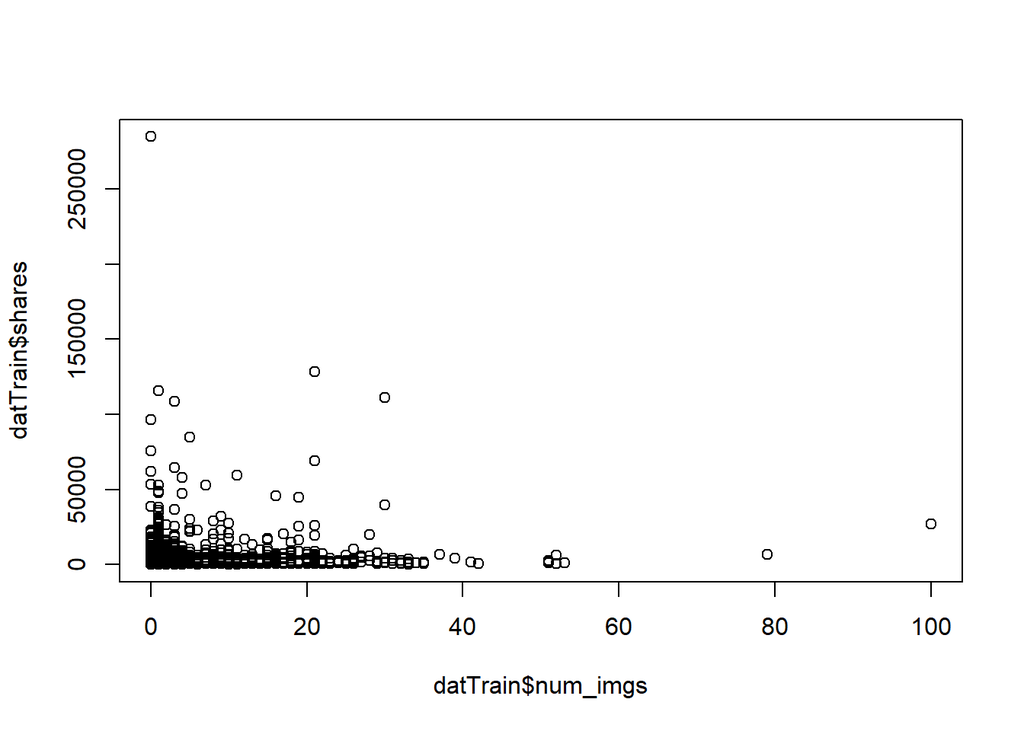

```r
plot(datTrain$shares~datTrain$num_imgs)
```

### Title Subjectivity vs Shares

We can inspect the trend of shares as a function of title subjectivity. If the points show an upward trend, then articles with higher title subjectivity tend to be shared more often. If the points show a downward trend, then articles with lower title subjectivity tend to be shared more often.

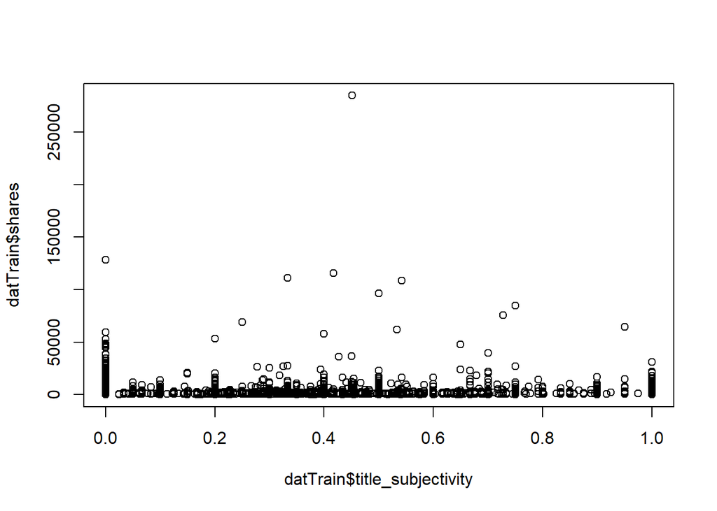

```r
plot(datTrain$shares~datTrain$title_subjectivity)
```

### Average Number of Keywords vs Shares

We can inspect the trend of shares as a function of number of keywords. If the bars show an upward trend, then articles with more keywords tend to be shared more often. If the bars show a downward trend, then articles with less keywords tend to be shared more often.

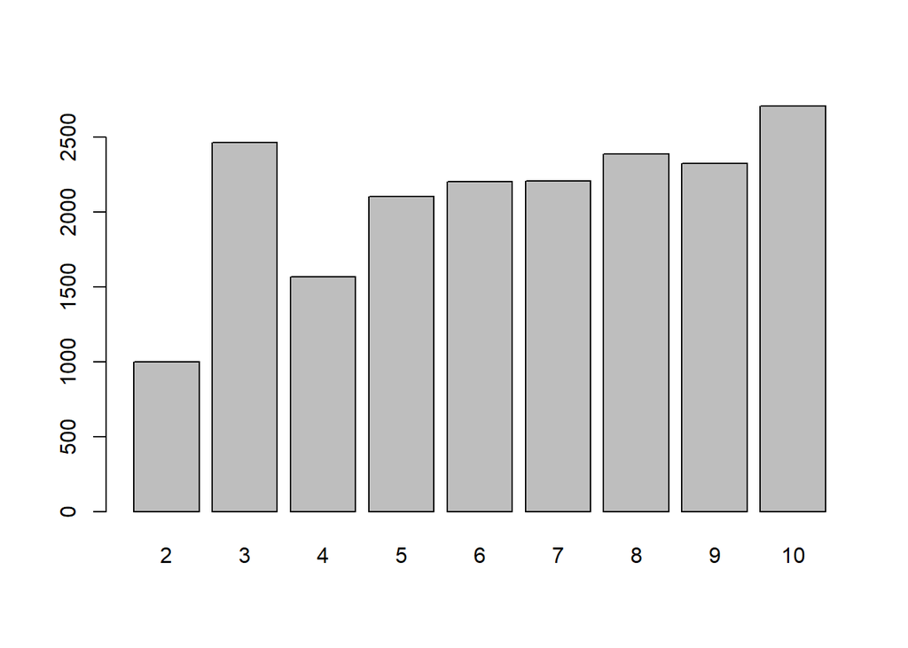

```r
datTrain$num_keywords <- as.factor(datTrain$num_keywords)
means <- datTrain %>%
  group_by(num_keywords) %>%
  summarise_at(vars(shares), list(name = mean))
barplot(height=means$name, names=means$num_keywords)
```

```r
# back to numeric for later models
datTrain$num_keywords <- as.numeric(datTrain$num_keywords)
```

### Images vs Videos

We can inspect possible relationships between the number of images and videos in an article. If some type of relationship is evident (e.g., articles with more images tend to have more videos), it may suggest some collinearity between these two variables.

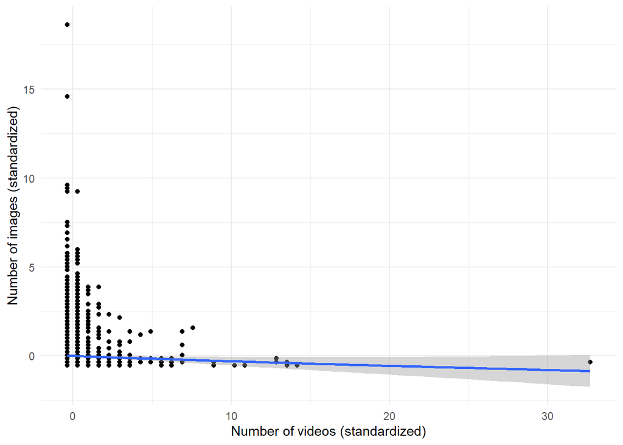

```r
g <- ggplot(datTrain, aes(x = scale(num_videos), y = scale(num_imgs)))

g + geom_point() +
    xlab("Number of videos (standardized)") +
    ylab("Number of images (standardized)") +
    geom_smooth() +
    theme_minimal()
```

### Positive vs negative word rates

We can inspect the relationship between positive and negative word rates in articles. If some type of relationship is evident (e.g., articles with higher positive word rates tend to have lower negative word rates), it may suggest some collinearity between these two variables.

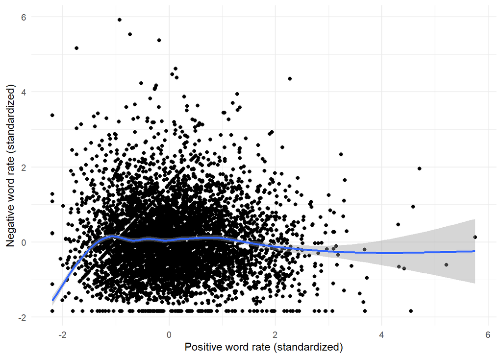

```r
g <- ggplot(datTrain, aes(x = scale(global_rate_positive_words), y = scale(global_rate_negative_words)))

g + geom_point() +
    xlab("Positive word rate (standardized)") +
    ylab("Negative word rate (standardized)") +
    geom_smooth() +
    theme_minimal()
```

### Title subjectivity by day of week

We can inspect the relationship between title subjectivity and the day of the week to see if certain days tend to have more/less subjective article titles.

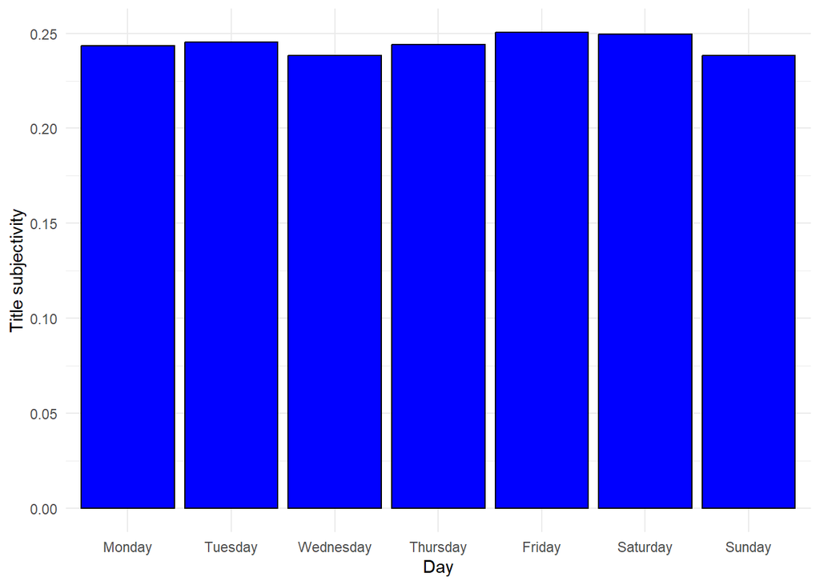

```r
g <- ggplot(datTrain, aes(x = day, y = title_subjectivity))

g + geom_bar(stat = "summary", fun = "mean", color = "black", fill = "blue") +
    xlab("Day") + ylab("Title subjectivity") +
    theme_minimal()
```

# Modeling

Linear regression is an analysis method wherein the values of a variable (i.e., response variable) is predicted based upon the value of one more more other variables (i.e., predictor variables). There is an underlying assumption that there is a linear relationship between the response variable and any given predictor. The slope of this line is determined mathematically by minimizing the sum of the squared residuals.

## Linear Models

This first model will explore the impact of images as combined with number of key words, title subjectivity, sentiment polarity, and positive word rate.

```r
#Train model
LinearModel1 <- train(shares ~ num_imgs+num_keywords+title_subjectivity+
                global_subjectivity+global_sentiment_polarity +
                global_rate_positive_words,
              data = datTrain,
              method = "lm",
              preProcess = c("center", "scale"),
              trControl = trainControl(method = "cv", number = 5))

summary(LinearModel1)
```

```
##
## Call:
## lm(formula = .outcome ~ ., data = dat)
##
## Residuals:
##    Min     1Q Median     3Q    Max
##  -6266  -1423  -1002   -347 282468
##
## Coefficients:
##                            Estimate Std. Error t value Pr(>|t|)
## (Intercept)                 2292.08      83.82  27.345  < 2e-16 ***
## num_imgs                     530.83      85.97   6.175 7.07e-10 ***
## num_keywords                 167.11      84.92   1.968   0.0491 *
## title_subjectivity           190.73      84.91   2.246   0.0247 *
## global_subjectivity          130.43     101.12   1.290   0.1971
## global_sentiment_polarity     51.97     107.73   0.482   0.6295
## global_rate_positive_words    42.27     121.26   0.349   0.7274
## ---
## Signif. codes:  0 '***' 0.001 '**' 0.01 '*' 0.05 '.' 0.1 ' ' 1
##
## Residual standard error: 6437 on 5891 degrees of freedom
## Multiple R-squared:  0.009153,   Adjusted R-squared:  0.008144
## F-statistic:  9.07 on 6 and 5891 DF,  p-value: 6.763e-10
```

```r
#Run on test data
LinearModel1.predict <- predict(LinearModel1, newdata = datTest)

#Obtain RMSE from test set, which will be used in automated comparison
LinearModel1.compare <- postResample(LinearModel1.predict, obs = datTest$shares)
```

The second model explores the impact of videos instead of images. Keywords are retained as a variable. Instead of exploring subjectivity and postive word rates, this model explores the “negative” (i.e., global rate of negative words and maximum polarity of negative words). It also includes an interaction between the number of videos and number of keywords.

```r
#Train model
LinearModel2 <- train(shares ~ num_videos + num_keywords +
                 num_videos:num_keywords + global_rate_negative_words +                                     max_negative_polarity,
              data = datTrain,
              method = "lm",
              preProcess = c("center", "scale"),
              trControl = trainControl(method = "cv", number = 5))

summary(LinearModel2)
```

```
##
## Call:
## lm(formula = .outcome ~ ., data = dat)
##
## Residuals:
##    Min     1Q Median     3Q    Max
##  -5320  -1474  -1059   -373 281538
##
## Coefficients:
##                            Estimate Std. Error t value Pr(>|t|)
## (Intercept)                 2292.08      84.03  27.278  < 2e-16 ***
## num_videos                   293.53     279.04   1.052  0.29287
## num_keywords                 238.08      89.40   2.663  0.00776 **
## global_rate_negative_words  -176.05      84.54  -2.082  0.03734 *
## max_negative_polarity       -107.85      84.66  -1.274  0.20272
## `num_videos:num_keywords`    -19.84     279.95  -0.071  0.94349
## ---
## Signif. codes:  0 '***' 0.001 '**' 0.01 '*' 0.05 '.' 0.1 ' ' 1
##
## Residual standard error: 6453 on 5892 degrees of freedom
## Multiple R-squared:  0.004103,   Adjusted R-squared:  0.003258
## F-statistic: 4.855 on 5 and 5892 DF,  p-value: 0.0001959
```

```r
#Run on test data
LinearModel2.predict <- predict(LinearModel2, newdata = datTest)

#Obtain RMSE from test set, which will be used in automated comparison
LinearModel2.compare <- postResample(LinearModel2.predict, obs = datTest$shares)
```

## Ensemble Models

To streamline model fitting, we will first remove the previously created “day” variable.

```r
# this is regression, not classification
#removing previously created day variable for boosted tree model
datTrain <- datTrain[,-19]
datTest <- datTest[,-19]
```

Now to fit the ensemble models.

### Random Forest Model

Random forests are similar to bagging in the sense that multiple trees (i.e., a “forest”) are created from bootstrap samples of data, with the outcome of these trees averaged to form a conclusion. Unlike bagging, not all possible predictors are used in each tree when using a random forest- only a random subset is used for each tree. This in turn makes the trees less correlated with one another, which allows for a greater reduction in variation once the outcomes of all trees are averaged.

Below is a random forest model to predict shares:

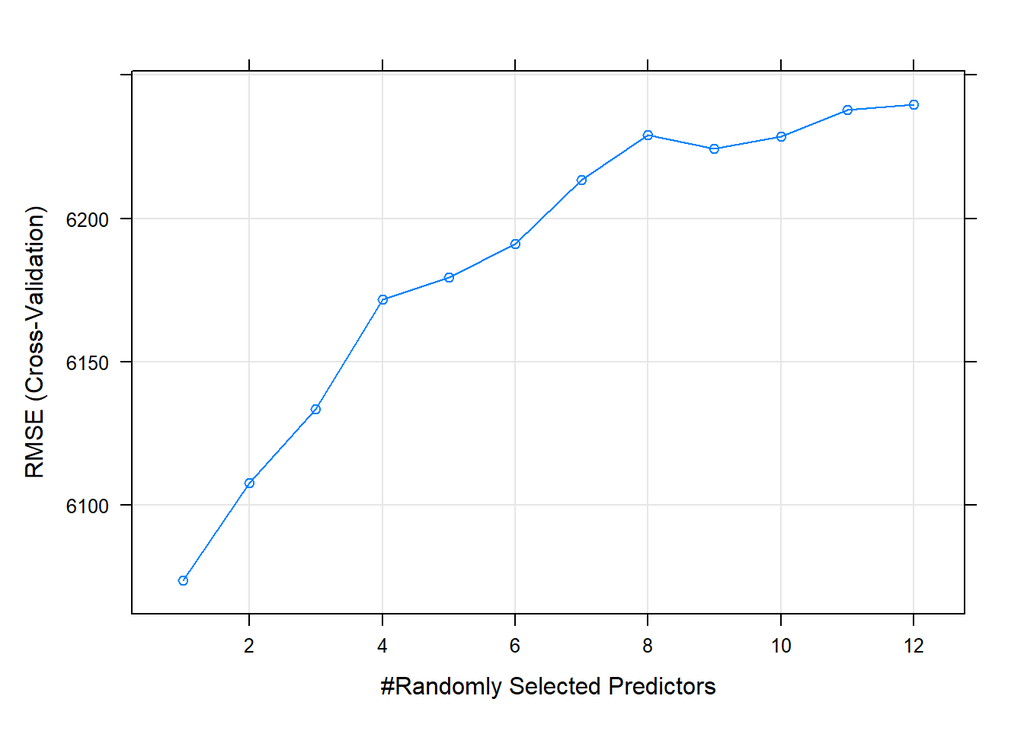

```r
#Create model. Constraining mtry to a max possible value of 12, which is ~1/3 of all possible variables
random.forest.fit <- train(shares ~ ., data = datTrain,
                           method = "rf",
                           preProcess = c("center", "scale"),
                           trControl = trainControl(method = "cv", number = 5),
                           tuneGrid = data.frame(mtry = 1:12))

# plot fit
plot(random.forest.fit)
```

```r
random.forest.fit$finalModel
```

```
##
## Call:
##  randomForest(x = x, y = y, mtry = param$mtry)
##                Type of random forest: regression
##                      Number of trees: 500
## No. of variables tried at each split: 1
##
##           Mean of squared residuals: 41513636
##                     % Var explained: 0.62
```

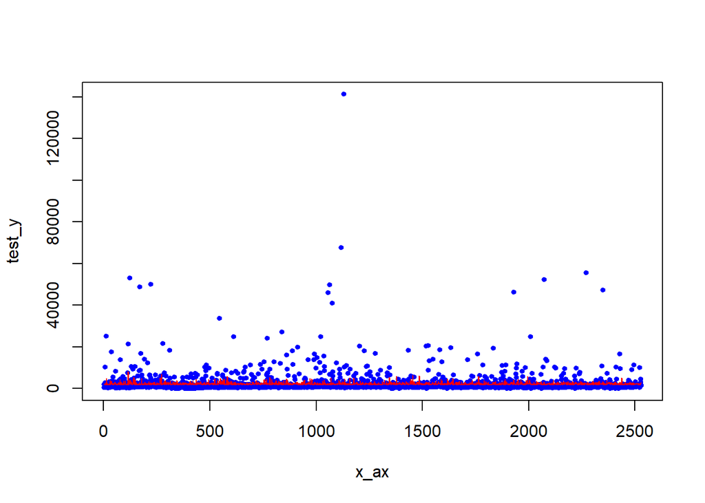

```r
# test fit
test_x = datTest[, -18]
test_y = datTest[, 18]
pred_y = predict(random.forest.fit, test_x)
x_ax = 1:length(pred_y)
x_ax <- as.numeric(x_ax)
test_y <- test_y$shares
test_y <- as.integer(test_y)
pred_y <- as.integer(pred_y)
plot(x_ax, test_y, col="blue", pch=20, cex=.9)
lines(x_ax, pred_y, col="red", pch=20, cex=.9)
```

```r
#Run on test data
random.forest.predict <- predict(random.forest.fit, newdata = datTest)

#Obtain RMSE from test set, which will be used in automated comparison
random.forest.compare <- postResample(random.forest.predict,
                                      obs = datTest$shares)
```

Here, the red lines are the predicted values for each observation. If the red lines are close to following the blue dots (which are representative of the actual value for each observation), then the model is closely predicting.

### Boosted Tree Model

Boosting is a general approach that can be applied to trees and allows for the slow training of trees. The trees are grown sequentially with each subsequent tree being grown on a modified version of the original data. The predictions are then updated as the trees are grown, and new trees are grown by considering the errors in the trees previously created. Lambda represents a shrinkage parameter than slows the fitting process.

Below is a boosted tree model to predict shares.

```r
boostFit <- train(shares~., data=datTrain, method="gbm",
                      preProcess=c("center","scale"),
                      trControl=trainControl(method='cv',number=5),
                      tuneGrid = expand.grid(n.trees=seq(25,200,50),
                                             interaction.depth=seq(1,4,1),
                                             shrinkage=0.1,
                                             n.minobsinnode=10))
```

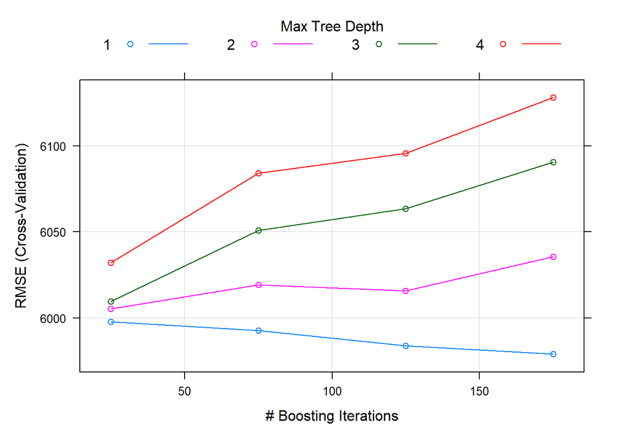

```r
# plot fit
plot(boostFit)
```

```r
boostFit$finalModel
```

```
## A gradient boosted model with gaussian loss function.
## 175 iterations were performed.
## There were 17 predictors of which 7 had non-zero influence.
```

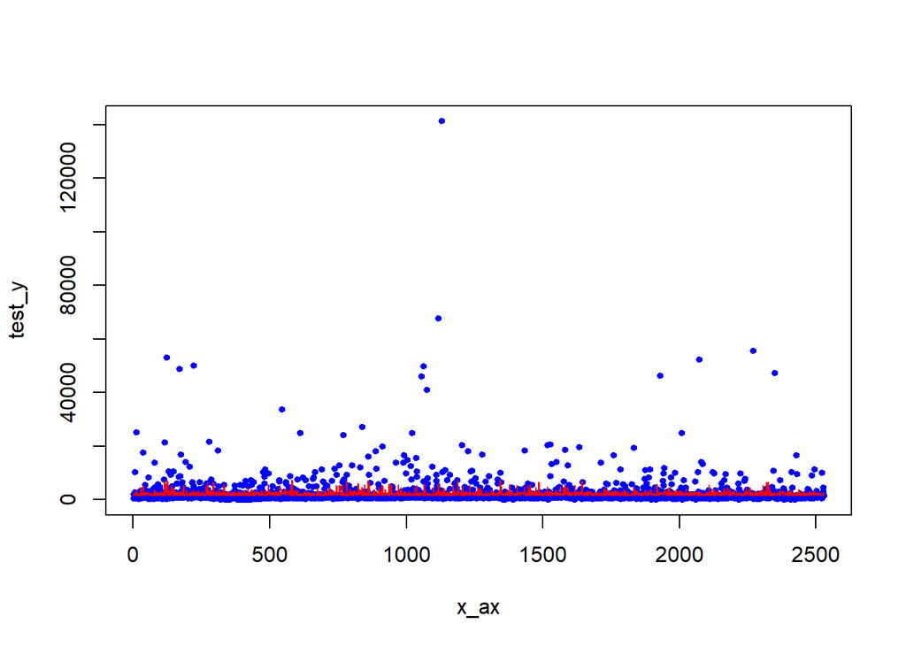

```r
# test fit
test_x = datTest[, -18]
test_y = datTest[, 18]
pred_y = predict(boostFit, test_x)
x_ax = 1:length(pred_y)
x_ax <- as.numeric(x_ax)
test_y <- test_y$shares
test_y <- as.integer(test_y)
pred_y <- as.integer(pred_y)
plot(x_ax, test_y, col="blue", pch=20, cex=.9)
lines(x_ax, pred_y, col="red", pch=20, cex=.9)
```

```r
#Run on test data
boostFit.predict <- predict(boostFit, newdata = datTest)

#Obtain RMSE from test set, which will be used in automated comparison
boostFit.compare <- postResample(boostFit.predict, obs = datTest$shares)
```

Here, the red lines are the predicted values for each observation. If the red lines are close to following the blue dots (which are representative of the actual value for each observation), then the model is closely predicting.

## Comparison

Now, grab all the RMSEs obtained from fitting the 4 models on the test set to determine the “winner.”

```r
#Compile RMSEs from the 4 models
LinearModel1.RMSE <- LinearModel1.compare[1]
LinearModel2.RMSE <- LinearModel2.compare[1]
random.forest.RMSE <- random.forest.compare[1]
boostFit.RMSE <- boostFit.compare[1]

compare.all <- data.frame(
                    model = c("First Linear", "Second Linear", "Random Forest",
                              "Boosted Tree"),
                    RMSE = c(LinearModel1.RMSE, LinearModel2.RMSE,
                             random.forest.RMSE, boostFit.RMSE))

winner <- compare.all %>% slice_min(order_by = RMSE)
```

The lowest RMSE obtained on the test set was **5057.93**, which belongs to the **Boosted Tree** model. Therefore, **Boosted Tree** is the winner!

The final standings of all 4 models can be seen below:

```r
compare.all %>% arrange(RMSE) %>% mutate(Final.Rank = rank(RMSE))
```

```
##           model     RMSE Final.Rank
## 1  Boosted Tree 5057.933          1
## 2 Random Forest 5084.376          2
## 3  First Linear 5091.680          3
## 4 Second Linear 5113.281          4
```